# BIOS 611 HW2 Data Transformation (Chapter 5)

Lang Li

##### Due Date: 09/10/18 (6pm)

This set of exercise is taken from R for Data Science by Garrett Grolemund and Hadley Wickham but modified slightly for the purpose of this class.

# Exercise 1

Note that the dataset `flights` is from the package `nycflights13`

1. Find all flights that (Shows all the rows with the following characteristics. Then for each problem, make a variable called ‘ans.flight.i’ where ‘i’ is replaced by the subproblem number(1,2,3,…) containing all these rows.)
   1. Had an arrival delay of two or more hours

```r
filter(flights,arr_delay >= 120)
```

```
## # A tibble: 10,200 x 19
##     year month   day dep_time sched_dep_time dep_delay arr_time
##    <int> <int> <int>    <int>          <int>     <dbl>    <int>
##  1  2013     1     1      811            630       101     1047
##  2  2013     1     1      848           1835       853     1001
##  3  2013     1     1      957            733       144     1056
##  4  2013     1     1     1114            900       134     1447
##  5  2013     1     1     1505           1310       115     1638
##  6  2013     1     1     1525           1340       105     1831
##  7  2013     1     1     1549           1445        64     1912
##  8  2013     1     1     1558           1359       119     1718
##  9  2013     1     1     1732           1630        62     2028
## 10  2013     1     1     1803           1620       103     2008
## # ... with 10,190 more rows, and 12 more variables: sched_arr_time <int>,
## #   arr_delay <dbl>, carrier <chr>, flight <int>, tailnum <chr>,
## #   origin <chr>, dest <chr>, air_time <dbl>, distance <dbl>, hour <dbl>,
## #   minute <dbl>, time_hour <dttm>
```

```
1. Flew to Houston (`IAH` or `HOU`)
```

```r
filter(flights,dest %in% c('IAH','HOU'))
```

```
## # A tibble: 9,313 x 19
##     year month   day dep_time sched_dep_time dep_delay arr_time
##    <int> <int> <int>    <int>          <int>     <dbl>    <int>
##  1  2013     1     1      517            515         2      830
##  2  2013     1     1      533            529         4      850
##  3  2013     1     1      623            627        -4      933
##  4  2013     1     1      728            732        -4     1041
##  5  2013     1     1      739            739         0     1104
##  6  2013     1     1      908            908         0     1228
##  7  2013     1     1     1028           1026         2     1350
##  8  2013     1     1     1044           1045        -1     1352
##  9  2013     1     1     1114            900       134     1447
## 10  2013     1     1     1205           1200         5     1503
## # ... with 9,303 more rows, and 12 more variables: sched_arr_time <int>,
## #   arr_delay <dbl>, carrier <chr>, flight <int>, tailnum <chr>,
## #   origin <chr>, dest <chr>, air_time <dbl>, distance <dbl>, hour <dbl>,
## #   minute <dbl>, time_hour <dttm>
```

```
1. Were operated by United, American, or Delta
```

```r
filter(flights,carrier %in% c('UA','AA','DL'))
```

```
## # A tibble: 139,504 x 19
##     year month   day dep_time sched_dep_time dep_delay arr_time
##    <int> <int> <int>    <int>          <int>     <dbl>    <int>
##  1  2013     1     1      517            515         2      830
##  2  2013     1     1      533            529         4      850
##  3  2013     1     1      542            540         2      923
##  4  2013     1     1      554            600        -6      812
##  5  2013     1     1      554            558        -4      740
##  6  2013     1     1      558            600        -2      753
##  7  2013     1     1      558            600        -2      924
##  8  2013     1     1      558            600        -2      923
##  9  2013     1     1      559            600        -1      941
## 10  2013     1     1      559            600        -1      854
## # ... with 139,494 more rows, and 12 more variables: sched_arr_time <int>,
## #   arr_delay <dbl>, carrier <chr>, flight <int>, tailnum <chr>,
## #   origin <chr>, dest <chr>, air_time <dbl>, distance <dbl>, hour <dbl>,
## #   minute <dbl>, time_hour <dttm>
```

```
1. Departed in summer (July, August, and September)
```

```r
filter(flights,month %in% c(7,8,9))
```

```
## # A tibble: 86,326 x 19
##     year month   day dep_time sched_dep_time dep_delay arr_time
##    <int> <int> <int>    <int>          <int>     <dbl>    <int>
##  1  2013     7     1        1           2029       212      236
##  2  2013     7     1        2           2359         3      344
##  3  2013     7     1       29           2245       104      151
##  4  2013     7     1       43           2130       193      322
##  5  2013     7     1       44           2150       174      300
##  6  2013     7     1       46           2051       235      304
##  7  2013     7     1       48           2001       287      308
##  8  2013     7     1       58           2155       183      335
##  9  2013     7     1      100           2146       194      327
## 10  2013     7     1      100           2245       135      337
## # ... with 86,316 more rows, and 12 more variables: sched_arr_time <int>,
## #   arr_delay <dbl>, carrier <chr>, flight <int>, tailnum <chr>,
## #   origin <chr>, dest <chr>, air_time <dbl>, distance <dbl>, hour <dbl>,
## #   minute <dbl>, time_hour <dttm>
```

```
1. Arrived more than two hours late, but didn't leave late
```

```r
filter(flights, dep_delay <= 0, arr_delay > 120)
```

```
## # A tibble: 29 x 19
##     year month   day dep_time sched_dep_time dep_delay arr_time
##    <int> <int> <int>    <int>          <int>     <dbl>    <int>
##  1  2013     1    27     1419           1420        -1     1754
##  2  2013    10     7     1350           1350         0     1736
##  3  2013    10     7     1357           1359        -2     1858
##  4  2013    10    16      657            700        -3     1258
##  5  2013    11     1      658            700        -2     1329
##  6  2013     3    18     1844           1847        -3       39
##  7  2013     4    17     1635           1640        -5     2049
##  8  2013     4    18      558            600        -2     1149
##  9  2013     4    18      655            700        -5     1213
## 10  2013     5    22     1827           1830        -3     2217
## # ... with 19 more rows, and 12 more variables: sched_arr_time <int>,
## #   arr_delay <dbl>, carrier <chr>, flight <int>, tailnum <chr>,
## #   origin <chr>, dest <chr>, air_time <dbl>, distance <dbl>, hour <dbl>,
## #   minute <dbl>, time_hour <dttm>
```

```
1. Were delayed by at least an hour, but made up over 30 minutes in flight
```

```r
filter(flights, dep_delay >= 60, dep_delay - arr_delay > 30)
```

```
## # A tibble: 1,844 x 19
##     year month   day dep_time sched_dep_time dep_delay arr_time
##    <int> <int> <int>    <int>          <int>     <dbl>    <int>
##  1  2013     1     1     2205           1720       285       46
##  2  2013     1     1     2326           2130       116      131
##  3  2013     1     3     1503           1221       162     1803
##  4  2013     1     3     1839           1700        99     2056
##  5  2013     1     3     1850           1745        65     2148
##  6  2013     1     3     1941           1759       102     2246
##  7  2013     1     3     1950           1845        65     2228
##  8  2013     1     3     2015           1915        60     2135
##  9  2013     1     3     2257           2000       177       45
## 10  2013     1     4     1917           1700       137     2135
## # ... with 1,834 more rows, and 12 more variables: sched_arr_time <int>,
## #   arr_delay <dbl>, carrier <chr>, flight <int>, tailnum <chr>,
## #   origin <chr>, dest <chr>, air_time <dbl>, distance <dbl>, hour <dbl>,
## #   minute <dbl>, time_hour <dttm>
```

```
1. Departed between midnight and 6am (inclusive)
```

```r
filter(flights, dep_time <= 600 | dep_time == 2400)
```

```
## # A tibble: 9,373 x 19
##     year month   day dep_time sched_dep_time dep_delay arr_time
##    <int> <int> <int>    <int>          <int>     <dbl>    <int>
##  1  2013     1     1      517            515         2      830
##  2  2013     1     1      533            529         4      850
##  3  2013     1     1      542            540         2      923
##  4  2013     1     1      544            545        -1     1004
##  5  2013     1     1      554            600        -6      812
##  6  2013     1     1      554            558        -4      740
##  7  2013     1     1      555            600        -5      913
##  8  2013     1     1      557            600        -3      709
##  9  2013     1     1      557            600        -3      838
## 10  2013     1     1      558            600        -2      753
## # ... with 9,363 more rows, and 12 more variables: sched_arr_time <int>,
## #   arr_delay <dbl>, carrier <chr>, flight <int>, tailnum <chr>,
## #   origin <chr>, dest <chr>, air_time <dbl>, distance <dbl>, hour <dbl>,
## #   minute <dbl>, time_hour <dttm>
```

2. Another useful dplyr filtering helper is `between()`. What does it do? Can you use it to simplify the code needed to answer the previous challenges? (Write the code using between() for subproblem 7 in the previous problem)

The `between(x,left,right)` option finds the value of x that falls in between of left and right.

```r
filter(flights, between(dep_time,0,600)|dep_time == 2400)
```

```
## # A tibble: 9,373 x 19
##     year month   day dep_time sched_dep_time dep_delay arr_time
##    <int> <int> <int>    <int>          <int>     <dbl>    <int>
##  1  2013     1     1      517            515         2      830
##  2  2013     1     1      533            529         4      850
##  3  2013     1     1      542            540         2      923
##  4  2013     1     1      544            545        -1     1004
##  5  2013     1     1      554            600        -6      812
##  6  2013     1     1      554            558        -4      740
##  7  2013     1     1      555            600        -5      913
##  8  2013     1     1      557            600        -3      709
##  9  2013     1     1      557            600        -3      838
## 10  2013     1     1      558            600        -2      753
## # ... with 9,363 more rows, and 12 more variables: sched_arr_time <int>,
## #   arr_delay <dbl>, carrier <chr>, flight <int>, tailnum <chr>,
## #   origin <chr>, dest <chr>, air_time <dbl>, distance <dbl>, hour <dbl>,
## #   minute <dbl>, time_hour <dttm>
```

3. How many flights have a missing `dep_time`? (Make a varible called “num.flights.missing.dep” for this number) What other variables are missing? (Make a variable called “missing.var” containing the name of these missing varaibles) What might these rows represent?

   Answer: 8255 flights are missing

```r
flight.missing.dep <- filter(flights, is.na(dep_time))
nrow(flight.missing.dep)
```

```
## [1] 8255
```

```
So let's find other missing values:
```

```r
missing.var <- c()
for (i in 1:19){
  if (sum(is.na(flight.missing.dep[i]))){
    missing.var = c(missing.var,names(flight.missing.dep)[i])
  }
}
missing.var
```

```
## [1] "dep_time"  "dep_delay" "arr_time"  "arr_delay" "tailnum"   "air_time"
```

So, since these time are all missing, we can say those are canceled flights.

4. Why is `NA ^ 0` not missing? Why is `NA | TRUE` not missing? Why is `FALSE & NA` not missing? Can you figure out the general rule? (`NA * 0` is a tricky counterexample!)

   (Hint: Think about what NA means and think logically why the expressions above can be evaluated.)

   Answer: Because everything to the power of 0 is 1. NA| TRUE uses the `or` operator, so it will execute TRUE. `FALSE&NA` will execute FALSE as anything NA is false, which is not NA. So NA * 0 is not working because NA can be infinite and infinity times 0 is not a number, thus will return NaN in R.

# Exercise 2

1. How could you use `arrange()` to sort all missing values to the start? (Hint: use `is.na()`). Make a variable called “missing.first” for this sorted tibble.

```r
missing.first <- arrange(flights, desc(is.na(dep_time)), dep_time)
missing.first
```

```
## # A tibble: 336,776 x 19
##     year month   day dep_time sched_dep_time dep_delay arr_time
##    <int> <int> <int>    <int>          <int>     <dbl>    <int>
##  1  2013     1     1       NA           1630        NA       NA
##  2  2013     1     1       NA           1935        NA       NA
##  3  2013     1     1       NA           1500        NA       NA
##  4  2013     1     1       NA            600        NA       NA
##  5  2013     1     2       NA           1540        NA       NA
##  6  2013     1     2       NA           1620        NA       NA
##  7  2013     1     2       NA           1355        NA       NA
##  8  2013     1     2       NA           1420        NA       NA
##  9  2013     1     2       NA           1321        NA       NA
## 10  2013     1     2       NA           1545        NA       NA
## # ... with 336,766 more rows, and 12 more variables: sched_arr_time <int>,
## #   arr_delay <dbl>, carrier <chr>, flight <int>, tailnum <chr>,
## #   origin <chr>, dest <chr>, air_time <dbl>, distance <dbl>, hour <dbl>,
## #   minute <dbl>, time_hour <dttm>
```

2. Sort `flights` to find the most delayed flights.(Make a variable called “delayed.sorted” for this sorted tibble).

```r
delayed.sorted = arrange(flights,desc(dep_delay))
delayed.sorted
```

```
## # A tibble: 336,776 x 19
##     year month   day dep_time sched_dep_time dep_delay arr_time
##    <int> <int> <int>    <int>          <int>     <dbl>    <int>
##  1  2013     1     9      641            900      1301     1242
##  2  2013     6    15     1432           1935      1137     1607
##  3  2013     1    10     1121           1635      1126     1239
##  4  2013     9    20     1139           1845      1014     1457
##  5  2013     7    22      845           1600      1005     1044
##  6  2013     4    10     1100           1900       960     1342
##  7  2013     3    17     2321            810       911      135
##  8  2013     6    27      959           1900       899     1236
##  9  2013     7    22     2257            759       898      121
## 10  2013    12     5      756           1700       896     1058
## # ... with 336,766 more rows, and 12 more variables: sched_arr_time <int>,
## #   arr_delay <dbl>, carrier <chr>, flight <int>, tailnum <chr>,
## #   origin <chr>, dest <chr>, air_time <dbl>, distance <dbl>, hour <dbl>,
## #   minute <dbl>, time_hour <dttm>
```

3. Sort `flights` to find the fastest flights (Make a variable called “fastest.flights” containing the rows with the fastest flights in terms of average speed).

```r
flight.speed <- flights %>% mutate(speed = distance / air_time) #Use `mutate()` method to calculate the speed of each flight
fastest.flight <- arrange(flight.speed, desc(speed))
fastest.flight
```

```
## # A tibble: 336,776 x 20
##     year month   day dep_time sched_dep_time dep_delay arr_time
##    <int> <int> <int>    <int>          <int>     <dbl>    <int>
##  1  2013     5    25     1709           1700         9     1923
##  2  2013     7     2     1558           1513        45     1745
##  3  2013     5    13     2040           2025        15     2225
##  4  2013     3    23     1914           1910         4     2045
##  5  2013     1    12     1559           1600        -1     1849
##  6  2013    11    17      650            655        -5     1059
##  7  2013     2    21     2355           2358        -3      412
##  8  2013    11    17      759            800        -1     1212
##  9  2013    11    16     2003           1925        38       17
## 10  2013    11    16     2349           2359       -10      402
## # ... with 336,766 more rows, and 13 more variables: sched_arr_time <int>,
## #   arr_delay <dbl>, carrier <chr>, flight <int>, tailnum <chr>,
## #   origin <chr>, dest <chr>, air_time <dbl>, distance <dbl>, hour <dbl>,
## #   minute <dbl>, time_hour <dttm>, speed <dbl>
```

4. Which flights travelled the longest? Which travelled the shortest? (Make a variable called “longest.flight” and “shortest.flight” for the rows with the longest and shortest flight)

```r
longest.flight <- head(arrange(flights,desc(air_time)),1)
shortest.flight <- head(arrange(flights,air_time),1)
longest.flight
```

```
## # A tibble: 1 x 19
##    year month   day dep_time sched_dep_time dep_delay arr_time
##   <int> <int> <int>    <int>          <int>     <dbl>    <int>
## 1  2013     3    17     1337           1335         2     1937
## # ... with 12 more variables: sched_arr_time <int>, arr_delay <dbl>,
## #   carrier <chr>, flight <int>, tailnum <chr>, origin <chr>, dest <chr>,
## #   air_time <dbl>, distance <dbl>, hour <dbl>, minute <dbl>,
## #   time_hour <dttm>
```

```r
shortest.flight
```

```
## # A tibble: 1 x 19
##    year month   day dep_time sched_dep_time dep_delay arr_time
##   <int> <int> <int>    <int>          <int>     <dbl>    <int>
## 1  2013     1    16     1355           1315        40     1442
## # ... with 12 more variables: sched_arr_time <int>, arr_delay <dbl>,
## #   carrier <chr>, flight <int>, tailnum <chr>, origin <chr>, dest <chr>,
## #   air_time <dbl>, distance <dbl>, hour <dbl>, minute <dbl>,
## #   time_hour <dttm>
```

# Exercise 3

1.Brainstorm as many ways as possible to select `dep_time`, `dep_delay`, `arr_time`, and `arr_delay` from `flights`.

```r
select(flights, dep_time, dep_delay, arr_time, arr_delay)
```

```
## # A tibble: 336,776 x 4
##    dep_time dep_delay arr_time arr_delay
##       <int>     <dbl>    <int>     <dbl>
##  1      517         2      830        11
##  2      533         4      850        20
##  3      542         2      923        33
##  4      544        -1     1004       -18
##  5      554        -6      812       -25
##  6      554        -4      740        12
##  7      555        -5      913        19
##  8      557        -3      709       -14
##  9      557        -3      838        -8
## 10      558        -2      753         8
## # ... with 336,766 more rows
```

```r
select(flights, starts_with("dep_"), starts_with("arr_"))
```

```
## # A tibble: 336,776 x 4
##    dep_time dep_delay arr_time arr_delay
##       <int>     <dbl>    <int>     <dbl>
##  1      517         2      830        11
##  2      533         4      850        20
##  3      542         2      923        33
##  4      544        -1     1004       -18
##  5      554        -6      812       -25
##  6      554        -4      740        12
##  7      555        -5      913        19
##  8      557        -3      709       -14
##  9      557        -3      838        -8
## 10      558        -2      753         8
## # ... with 336,766 more rows
```

```r
flights[,c(4,6,7,9)]
```

```
## # A tibble: 336,776 x 4
##    dep_time dep_delay arr_time arr_delay
##       <int>     <dbl>    <int>     <dbl>
##  1      517         2      830        11
##  2      533         4      850        20
##  3      542         2      923        33
##  4      544        -1     1004       -18
##  5      554        -6      812       -25
##  6      554        -4      740        12
##  7      555        -5      913        19
##  8      557        -3      709       -14
##  9      557        -3      838        -8
## 10      558        -2      753         8
## # ... with 336,766 more rows
```

```r
select(flights, matches("^(dep|arr)_(time|delay)$"))
```

```
## # A tibble: 336,776 x 4
##    dep_time dep_delay arr_time arr_delay
##       <int>     <dbl>    <int>     <dbl>
##  1      517         2      830        11
##  2      533         4      850        20
##  3      542         2      923        33
##  4      544        -1     1004       -18
##  5      554        -6      812       -25
##  6      554        -4      740        12
##  7      555        -5      913        19
##  8      557        -3      709       -14
##  9      557        -3      838        -8
## 10      558        -2      753         8
## # ... with 336,766 more rows
```

2. What happens if you include the name of a variable multiple times in a `select()` call?

   Answer: It will include the variable only once.
3. What does the `one_of()` function do? Why might it be helpful in conjunction with this vector?

   Answer: `one_of()` function select variables in character vector. I think it is easier to find the vector using the character vectors.

   ```r
   vars <- c("year", "month", "day", "dep_delay", "arr_delay")
   select(flights, one_of(vars))
   ```

   ```
   ## # A tibble: 336,776 x 5
   ##     year month   day dep_delay arr_delay
   ##    <int> <int> <int>     <dbl>     <dbl>
   ##  1  2013     1     1         2        11
   ##  2  2013     1     1         4        20
   ##  3  2013     1     1         2        33
   ##  4  2013     1     1        -1       -18
   ##  5  2013     1     1        -6       -25
   ##  6  2013     1     1        -4        12
   ##  7  2013     1     1        -5        19
   ##  8  2013     1     1        -3       -14
   ##  9  2013     1     1        -3        -8
   ## 10  2013     1     1        -2         8
   ## # ... with 336,766 more rows
   ```

# Exercise 4

1. Currently `dep_time` and `sched_dep_time` are convenient to look at, but hard to compute with because they’re not really continuous numbers. Convert them to a more convenient representation of number of minutes since midnight. (Replace the variable “flights” with this tibble with converted dep_time and sched_dep_time)

```r
flights <- flights %>%
       mutate(dep_time_mins = dep_time %/% 100 * 60 + dep_time %% 100,
       sched_dep_time_mins = sched_dep_time %/% 100 * 60 + sched_dep_time %% 100) %>%
       select(-dep_time,-sched_dep_time)
```

2. Compare `air_time` with `arr_time - dep_time`. What do you expect to see? What do you see? What do you need to do to fix it?

   Answer: I expect them to be the same with minor difference of those who depart at 2400. However, many of them are different. The reason behind that is the time zone difference. We can create several standardized time representation to fix the issue.
3. Compare `dep_time`, `sched_dep_time`, and `dep_delay`. How would you expect those three numbers to be related?

   Answer: `dep_time` = `sched_dep_time` + `dep_delay`
4. Find the 10 most delayed flights using a ranking function.(Name this variable “top.delayed” containing the rows) How do you want to handle ties? Carefully read the documentation for `min_rank()`.

   Answer:

```r
top_delayed <- flights %>%
  mutate(dep_delay_rank = min_rank(arr_delay)) %>%
  arrange(desc(dep_delay_rank)) %>%
  head(10)
top_delayed
```

```
## # A tibble: 10 x 20
##     year month   day dep_delay arr_time sched_arr_time arr_delay carrier
##    <int> <int> <int>     <dbl>    <int>          <int>     <dbl> <chr>
##  1  2013     1     9      1301     1242           1530      1272 HA
##  2  2013     6    15      1137     1607           2120      1127 MQ
##  3  2013     1    10      1126     1239           1810      1109 MQ
##  4  2013     9    20      1014     1457           2210      1007 AA
##  5  2013     7    22      1005     1044           1815       989 MQ
##  6  2013     4    10       960     1342           2211       931 DL
##  7  2013     3    17       911      135           1020       915 DL
##  8  2013     7    22       898      121           1026       895 DL
##  9  2013    12     5       896     1058           2020       878 AA
## 10  2013     5     3       878     1250           2215       875 MQ
## # ... with 12 more variables: flight <int>, tailnum <chr>, origin <chr>,
## #   dest <chr>, air_time <dbl>, distance <dbl>, hour <dbl>, minute <dbl>,
## #   time_hour <dttm>, dep_time_mins <dbl>, sched_dep_time_mins <dbl>,
## #   dep_delay_rank <int>
```

5. What does `1:3 + 1:10` return? Why?

   Answer: It returns as shown below. It is reusing the shorter length vector for adding the long one. So we are seeing `c(1+1,2+2,3+3,1+4,2+5,3+6,1+7,2+8,3+9,1+10)`.

```r
1:3 + 1:10
```

```
##  [1]  2  4  6  5  7  9  8 10 12 11
```

# Exercise 5

1. Brainstorm at least 3 different ways to assess the typical delay characteristics of a group of flights. Consider the following scenarios:
   - A flight is 15 minutes early 50% of the time, and 15 minutes late 50% of the time.
   - A flight is always 10 minutes late.
   - A flight is 30 minutes early 50% of the time, and 30 minutes late 50% of the time.
   - 99% of the time a flight is on time. 1% of the time it’s 2 hours late.

   Which is more important: arrival delay or departure delay?  
   (Make 3 similar statements as the ones above using the data we have) Answer: We want to initiate a scoring system. There are several methods. I think arrival delay is a huge problem as it may affect the further travel of the passengers. We can think of a scoring system to characterize the delay. We can calculate the average delay time if delayed. If the performance is consistent, we will give it a factor of 1. If it is not consistent, which is pretty bad for the connecting passengers, then we will give it a factor of 2 or more based on how inconsistent it is so that passenger can be well prepared. Another way we can do is to give a threshold to report the delay. Like the last scenario, if only 1% of the time the plane will delay, it was probably due to weather reason, so we would consider it a perfect flight. So we can add a threshold, like 10% of the time. We can incorporate the severeness of the delay. So we would classify flight that has 10% chance, 30%, 50% or even greater chance of delay and consider that into making a score of the delay. We can also consider the overall delayed time per year and do a weighted average. But I think this would disadvantage the last flight scenrio.
2. Look at the number of cancelled flights per day. Is there a pattern? Is the proportion of cancelled flights related to the average delay?

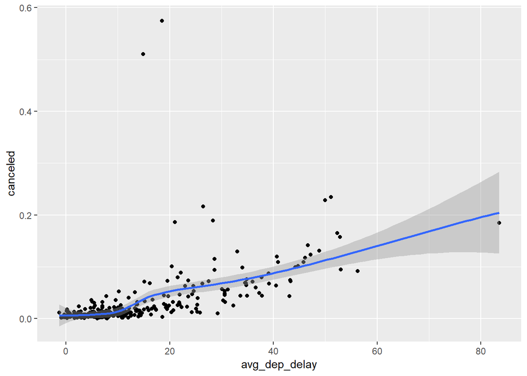

```r
canceled_delayed <- flights %>%
  mutate(canceled = (is.na(arr_delay))) %>%
  group_by(year, month, day) %>%
  summarise(canceled = mean(canceled),
            avg_dep_delay = mean(dep_delay, na.rm = TRUE))

ggplot(canceled_delayed, aes(x = avg_dep_delay, canceled)) +
  geom_point() +
  geom_smooth()
```

3. Which carrier has the worst delays?

Answer: The carrier F9, Frontier Airlines.

```r
flights %>%
  group_by(carrier) %>%
  summarise(arr_delay = mean(arr_delay, na.rm = TRUE)) %>%
  arrange(desc(arr_delay)) %>%
  head(1)
```

```
## # A tibble: 1 x 2
##   carrier arr_delay
##   <chr>       <dbl>
## 1 F9           21.9
```

4. What does the `sort` argument to `count()` do. When might you use it?

   Answer: The `sort` argument sort the `count()` result by n. You will want to use it every time you want to use show something in a certain order.

# Exercise 6

1. Which plane (`tailnum`) has the worst on-time record? (Make a variable called “worst.plane” for this plane tail number)

N844MH has a worst arrival delay… WOW, I checked the flightradar24 and it is a Delta Airline 767 with SKYTEAM livery. What a special plane!

```r
worst.plane <- flights %>%
  group_by(tailnum) %>%
  summarise(arr_delay = mean(arr_delay, na.rm = TRUE)) %>%
  arrange(desc(arr_delay)) %>%
  head(1)
worst.plane
```

```
## # A tibble: 1 x 2
##   tailnum arr_delay
##   <chr>       <dbl>
## 1 N844MH        320
```

2. For each destination, compute the total minutes of delay. (Make a tibble called “dest.delayedmin” with these two columns)

```r
dest.delayedmin <- flights %>%
  group_by(dest) %>%
  summarise(arr_delay = sum(arr_delay, na.rm = TRUE))
dest.delayedmin
```

```
## # A tibble: 105 x 2
##    dest  arr_delay
##    <chr>     <dbl>
##  1 ABQ        1113
##  2 ACK        1281
##  3 ALB        6018
##  4 ANC         -20
##  5 ATL      190260
##  6 AUS       14514
##  7 AVL        2089
##  8 BDL        2904
##  9 BGR        2874
## 10 BHM        4540
## # ... with 95 more rows
```

3. Delays are typically temporally correlated: even once the problem that caused the initial delay has been resolved, later flights are delayed to allow earlier flights to leave. Using `lag()`, explore how the delay of a flight is related to the delay of the immediately preceding flight. (What proportion of delayed flights is caused by the delay of the immediately preceding flights)

Answer: From the graph, we can easily see that previous delay has caused the later flight to delay.

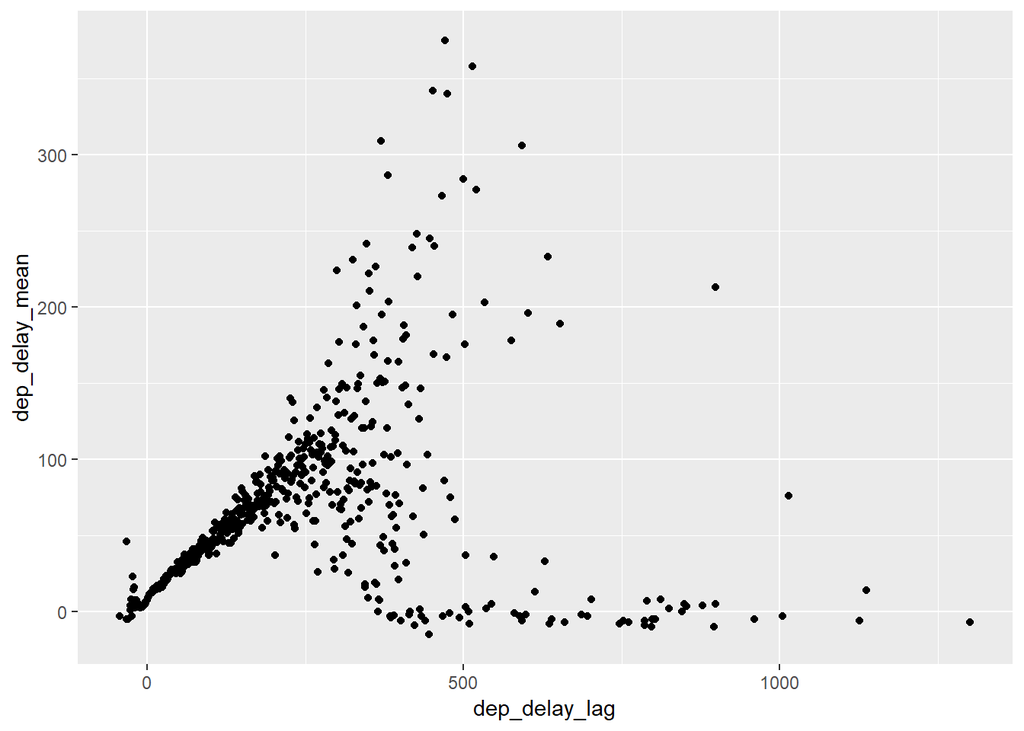

```r
lagged_delays <- flights %>%
  arrange(origin, year, month, day, dep_time_mins) %>%
  group_by(origin) %>%
  mutate(dep_delay_lag = lag(dep_delay)) %>%
  filter(!is.na(dep_delay), !is.na(dep_delay_lag))

lagged_delays %>%
  group_by(dep_delay_lag) %>%
  summarise(dep_delay_mean = mean(dep_delay)) %>%
  ggplot(aes(y = dep_delay_mean, x = dep_delay_lag)) +
  geom_point()
```

4. Find all destinations that are flown by at least two carriers. (Put these destinations into a variable called “popular.destinations”)

```r
popular.destinations <- flights %>%
  group_by(dest, carrier) %>%
  filter(row_number() == 1) %>%
  group_by(dest) %>%
  mutate(n_carrier = n_distinct(carrier)) %>%
  filter(n_carrier >= 2) %>%
  select(dest)
```

5. For each plane, count the number of flights before the first delay of greater than 1 hour. (Make a tibble called “plane.num.before.first.delay” with these two columns)

```r
plane.num.before.first.delay <- flights %>%
  arrange(tailnum, year, month, day) %>%
  group_by(tailnum) %>%
  mutate(delay_gt1hr = dep_delay > 60) %>%
  mutate(before_delay = cumsum(delay_gt1hr)) %>%
  filter(before_delay < 1) %>%
  count()
plane.num.before.first.delay
```

```
## # A tibble: 3,755 x 2
## # Groups:   tailnum [3,755]
##    tailnum     n
##    <chr>   <int>
##  1 N0EGMQ     39
##  2 N10156      9
##  3 N102UW     25
##  4 N103US     46
##  5 N104UW      3
##  6 N105UW     22
##  7 N107US     20
##  8 N108UW     36
##  9 N109UW     48
## 10 N110UW     15
## # ... with 3,745 more rows
```